# varsel

Utility-based variable selection to improve clinical utility of prediction models: the NBvarsel R package

Lasai Barreñada<sup>1,2</sup>, Andrew Vickers<sup>3</sup>, Laure Wynants<sup>1,2,4</sup>, Dirk Timmerman<sup>1,5</sup>, Ewout Steyerberg<sup>6</sup>, Ben Van Calster<sup>1,2,6</sup>

<sup>1</sup> Department of Development and Regeneration, KU Leuven, Belgium

<sup>2</sup> Leuven Unit for Health Technology Assessment Research (LUHTAR), KU Leuven, Belgium

<sup>3</sup> Department of Epidemiology and Biostatistics, Memorial Sloan Kettering Cancer Center, New York, NY, USA

<sup>4</sup> Department of Epidemiology, CAPHRI Care and Public Health Research Institute, Maastricht University, Maastricht, Netherlands

<sup>5</sup> Dept Obstetrics & Gynecology, University Hospitals Leuven, Leuven, Belgium.

<sup>6</sup>Julius Centre for Health Sciences and Primary Care, University Medical Centre Utrecht, Utrecht, Netherlands

Jamia: max 4000 words, 4 tables, 6 figures.

**Word count: ~5800**

**Corresponding author**

Ben Van Calster

KU Leuven, Department of Development and Regeneration

Herestraat 49 box 805

3000 Leuven

Belgium

ben.vancalster@kuleuven.be

**Abstract: 250 words max**

**Objective:** Variable selection (VS) for clinical prediction models is mostly done purely based on statistical grounds, either using information criteria or p-values. These approaches ignore the cost of misclassifications and the cost of measuring a variable. We propose a decision analytic VS based on net benefit and implement it in the open-source *NBvarsel* R package.

**Materials and Methods:** The proposed algorithm selects the set of predictors by exhaustively comparing the net benefit of all combinations using cross validation, with an extension based on backward elimination for large dimensional settings. It provides variable importance as the contribution of each predictor to the utility and allows the user to set cost of measuring a predictor. We illustrate the usage of the package in a simulation and test the performance in terms of discrimination, calibration clinical utility in three real case studies.

**Results:** Across the three case studies, *NBvarsel* obtained a more parsimonious model maintaining or improving the clinical utility with minimal loss of discrimination and calibration. If costs of selecting a predictor are considered the method rules out costly predictors that contribute little to utility.

**Discussion:** *NBvarsel* serves as a promising approach for integrating clinical utility directly into the variable selection process allowing prediction models to maximize patient benefit while minimizing unnecessary clinical burden.

**Conclusion:** We present an easy-to-use algorithm based on the utility that a model would have in the clinic to select the best subset of predictors, which leads to simpler models maintaining the same utility.

# Introduction

Determining a patient’s condition based on their current characteristics is called diagnosis and is key to initiate any treatment and minimize future complications. Different conditions require exploring different characteristics. For example, a bone fracture can be diagnosed through medical imaging and COVID-19 through a PCR test. Clinical prediction models are statistical tools that estimate the probability that a patient has or will develop a condition in the future [1]. These models try to link the outcome (event or condition) with a series of predictors in a dataset, a task often called supervised learning [2]. These predictors should be information readily available at the time of diagnosis, not too costly to measure and measured with reasonable precision [1]. However, there might be a vast number of predictors that meet these criteria and selecting among them is needed [3].

Variable selection, best subset selection, feature selection, and feature engineering are terms used in prediction modelling to describe the process of selecting which predictors to use when training a model. Different approaches for variable selection have been presented. Heinze and colleagues [4] categorized them into five groups based on the criteria to select the variables: (1) based on significance testing, (2) based on information criteria (e.g. AIC, BIC), (3) based on penalized likelihood (e.g. LASSO, elastic-net), (4) based on change-in-estimate or performance (e.g. backward elimination, stepwise selection), or (5) based on background or domain knowledge. Across machine learning literature, it is often observed that variable selection methods are grouped into filter, wrapper and embedded methods [5]. Filter methods use statistical properties to select variables and are therefore equivalent to significance testing and information criteria-based approaches. Wrapper methods, in contrast, use model performance to select the best subset, which corresponds to Heinze’s change-in-estimate criterion. Finally, embedded methods perform variable selection as part of the model training; this includes penalized likelihood but also other approaches such as feature importance calculation in tree-based or genetic algorithms [6,7]. This work will focus on change-in-estimate or wrapper methods for variable selection in clinical prediction models.

To be used in clinical practice, prediction models need to show good performance in external validation in terms of discrimination (area under the ROC curve), calibration (calibration plot), and clinical utility (Net Benefit, NB) [8]. Variable selection is usually performed by considering only the statistical properties of the predictors (filter methods), without accounting for the clinical benefit or utility. Utility refers to the quality of decision-making when a risk model is used to decide whether a patient requires treatment [9]. Models that are not clinically useful are more likely to be forgotten quickly or even never be implemented in real practice [10]. Consequently, we aim to include clinical utility in the model development process through a clinical utility guided variable selection.

Utility values, relating to misclassification costs (i.e., the benefit of treating the diseased and the harm of treating the healthy), are hard to elicit at an absolute scale. However, it is known that the ratio of harm to benefit is directly related to the decision threshold for classifying a patient as high risk [9]. NB, a simple metric for clinical utility, uses this relationship. NB is calculated as benefit minus harm multiplied by scaled by the harm-to-benefit ratio [11]. In statistical terms, this is the number of true positives minus the number of false positives weighted by the harm-to-benefit ratio. This ratio reflects how many false positives a clinician is willing to accept per true positive. For example, if a surgeon is willing to perform 9 surgeries on benign tumors to catch 1 malignant tumor, the exchange rate is 1/9, corresponding to a 10% decision threshold. However, NB should often be presented across a range of thresholds, given variability across clinicians and settings [12]. The use of NB and related metrics to evaluate a new variable was discussed by Baker and colleagues [13] but it has never been implemented as a variable selection algorithm for clinical prediction models.

The aim of this paper is therefore to develop a simple and interpretable variable selection algorithm based on clinical utility to determine which predictors to include in the model and implement it as an easy to use R package. Additionally, we will explore the effect on performance of the method. We will use and implement the method in the context of a logistic regression to estimate the probability of a binary outcome, but the rationale extends to more flexible machine learning or AI probabilistic algorithms.

# Methodology

## Algorithm

The proposed variable selection algorithm does not involve modifying coefficient estimation, since the logloss minimisation (or log-likelihood maximisation) is known to provide coefficients with good properties [14]. Therefore, the proposed algorithm works as follows:

- Define all possible model combinations based on the predictors:
- Assign a test tradeoff or (see section 2.3) to each predictor or group of predictors to adjust the NB accordingly. If the harm is unknown, this can be 0 and unadjusted NB will be used.
- Train models and evaluate their net benefit using cross validation with folds (default is 5).
  - This step can be parallelized to reduce computation time.
  - Nonlinearities can be addressed with restricted cubic splines.
  - Interactions can be included; we limit this option to either all pairwise interactions or no interactions.
- Rank the models based on NB and select the model with optimal NB.

Code implementing the NB based variable selection and the associated visualizations are available in the open-source R package *NBvarsel* **(**[**https://lasaibarrenada.github.io/NB_varsel/**](https://lasaibarrenada.github.io/NB_varsel/)**, Box 1)**

### Large dimensional settings

The algorithm presented in section 2.1 becomes computationally too demanding when the number of candidate predictors increases. For a dataset with 20 candidate predictors, there are more than one million predictor combinations; consequently, the method fits 5 million models when using 5-fold cross-validation. In most trials or observational studies, the sample size is limited; therefore, the number of candidate predictors should also be kept small. Our methodology should always be used in compliance with these sample size criteria as explained in section 2.2. However, in those cases where the dimensionality of the data is large (e.g. electronic health records), we propose an extension of the methodology that we called groupwise (as opposed to exhaustive) NB variable selection.

**Box 1: Implementing the Methodology in R**

Toy example with simulated data  
n <- 500  
df <- [data.frame](https://rdrr.io/r/base/data.frame.html)(  
X1 = [rnorm](https://rdrr.io/r/stats/Normal.html)(n), X2 = [rbinom](https://rdrr.io/r/stats/Binomial.html)(n, 1, 0.7),  
X3 = [rnorm](https://rdrr.io/r/stats/Normal.html)(n), X4 = [rbinom](https://rdrr.io/r/stats/Binomial.html)(n, 1, 0.5)  
)  
df$Y <- [rbinom](https://rdrr.io/r/stats/Binomial.html)(n, 1, [plogis](https://rdrr.io/r/stats/Logistic.html)(2 * df$X1 + 1.5 * df$X2 + 0.2 * df$X3))  
Step 1: Download package  
pak::[pak](https://pak.r-lib.org/reference/pak.html)(“LasaiBarrenada/NB_varsel”)  
# OR  
[install.packages](https://rdrr.io/r/utils/install.packages.html)(“NB_varsel”)  
Step 2: Define harms (optional)  
harms <- [c](https://rdrr.io/r/base/c.html)(X1 = 0.1, X2 = 0.05, X3 = 0.1, X4 = 0.0001)  
Step 3: Core function  
result <- [nb_varsel](https://lasaibarrenada.github.io/NB_varsel/reference/nb_varsel.html)(  
data = df, # data.frame containing the predictors and outcome  
outcome_var = “Y”,  
costs = harms,  
mode = “exhaustive”, # exhaustive or groupwise  
splines = FALSE, # whether splines are used for continuous predictors  
permutation = TRUE, # whether variable importance is calculated  
allow_parallel = FALSE # whether parallel computation is allowed  
)  
Step 4: Analysis of results  
# Best model (highest cost-adjusted Net Benefit)  
result$best_model_stats  
# All evaluated models, sorted by cost adjusted net benefit  
result$all_models  
Step 5: Built-in visualizations  
# Two-panel plot: metric overview + predictor inclusion heatmap  
[all_subset_plot](https://lasaibarrenada.github.io/NB_varsel/reference/all_subset_plot.html)(  
result$all_models,  
highlight_color = “steelblue”,  
tile_color = “#E64B35”  
)  
# Permutation importance bar chart  
[VIF_plot](https://lasaibarrenada.github.io/NB_varsel/reference/VIF_plot.html)(result$all_models, color = “darkgreen”)  
**Detailed and up to date documentation available at** [**https://lasaibarrenada.github.io/NB_varsel/**](https://lasaibarrenada.github.io/NB_varsel/)

## Note on Sample size

Across systematic reviews of prediction model development and validation studies, a common issue is that there is no rationale for the sample size used [15,16]. International guidelines for prediction modelling, such as TRIPOD+AI and PROBAST+AI, recommend always justifying sample size [17,18].

The ratio of the number of events and potential number of predictors is called events per variable (EPV) or events per potential predictor (EPP). We prefer the latter because it explicitly states that its value should always be based on **potential** predictors, prior to data-driven variable selection; otherwise, the coefficients will be biased [19]. In traditional logistic and linear regression, EPP indicates relationship between the number of coefficients to be estimated and the amount of available information. The first recommendations indicated that an EPP of greater than ten was adequate [20,21]. Some years later, several authors disputed this rule, concluding that there is no single EPP rule that would guarantee accurate estimation [22-24].

Moving beyond rules of thumb, Riley and colleagues have developed several minimum sample size calculation techniques for developing and validating multivariable binary, continuous and time-to-event models [25-30]. Recently, the group has published a general framework that applies both to linear models and to more flexible AI-based algorithms such as random forests [31], that had shown to be more “data hungry” [32,33]. These criteria are based on overfitting and optimism control and precise estimation of the intercept.

When sample data is limited, a two-stage approach is often recommended: first selecting a subset of predictors based on subject matter knowledge and then performing a data-driven variable selection [1,34]. **Because it is prone to overfitting like any data-driven process, the methodology presented here must always adhere to the recommended minimum sample size.**

## Test harms

**Box 2: Harm of a test and test tradeoff**

We acknowledge that determining the harm of measuring a predictor in the context of a model development study is challenging. In this box we propose some aspects to consider when determining the harms.

- **Harms are broad:** They go beyond monetary costs of a test, including patient burden, possible side effects, objectivity of the measurement, requirement of specific equipment for the measurement, time needed to undergo the test etc…
- **Harm for the model Harm of the test:** A predictor might be very costly for the general population, but in the context of the prediction model problem be readily available, because it is measured as part of the clinical routine.
- **Harms are context dependant:** harms depend on clinical context of the prediction model and setting and should be defined accordingly.
- **Combined harms:** Some test might cause harm but give information about several predictors. The harm of one or all those predictors should be equal.

In the algorithm presented the harms should be defined according to these aspects. We propose for that the **test tradeoff**. This can facilitate the process of setting the harms, determining those as the number of times a doctor would be willing to measure a predictor to find a new case. In case this is used, this should be defined carefully by experts before looking at the data.

For most cases where the harms cannot be clearly defined, we advise researchers NOT to use the harms and to select variables based on NB and analyse the contribution of each predictor to the total NB.

## Variable importance

When the TT or is difficult to quantify, an alternative approach to help decide which variable to include in a model is computing each variable’s contribution to the clinical utility. Variable importance is typically assessed using the statistical properties of the model being analysed. For instance, in a logistic regression model, coefficients can be used to compare the relative contribution of each predictor, while in random forest the Gini importance is often used to rank predictors by their contribution to the reduction of impurity. Other model-agnostic procedures have been proposed in the explainable AI field [35], such as the SHAP (SHapley Additive exPlanations) values and Local interpretable model-agnostic explanations (LIME) [36,37]. However, these techniques assess variable importance based on predicted probabilities rather than the clinical utility of the model. In his seminal paper introducing random forests, Breiman introduced permutation variable importance [38]. The algorithm proceeds as follows:

- A model is trained on training data.
- The performance of the model is evaluated on test or unobserved data.
- The performance of the model on test data is recalculated by randomly shuffling (permuting) values of a predictor .
- The variable importance of P is the difference between the performance on the true dataset and on the permuted dataset.

We apply this approach to calculate the average contribution of each predictor to the NB across the different predictor combinations evaluated. The permuted performance is calculated within the same folds of the cross-validation to ensure that the permuted and original performances are comparable. It is important to note that this variable importance is the average across all evaluated predictor combinations; therefore, the results might be distorted due to unrealistic combinations.

## Simple illustration

Table 1. Results for the simple illustration presented in section 2.3

| Included predictors | Total harm | NB | NB - harm | AUC | Brier |
| --- | --- | --- | --- | --- | --- |
| X1, X4<sup>a</sup> | 0.050 | 0.217 | 0.167 | 0.906 | 0.115 |
| X1 | 0.050 | 0.217 | 0.167 | 0.907 | 0.114 |
| X1, X2<sup>b</sup> | 0.075 | 0.231 | 0.156 | 0.925 | 0.102 |
| X1, X2, X4 | 0.075 | 0.230 | 0.155 | 0.925 | 0.102 |
| X1, X3 | 0.100 | 0.219 | 0.119 | 0.906 | 0.114 |
| X1, X3, X4 | 0.100 | 0.219 | 0.119 | 0.906 | 0.114 |
| X1, X2, X3<sup>c</sup> | 0.125 | 0.231 | 0.106 | 0.925 | 0.101 |
| X1, X2, X3, X4 | 0.125 | 0.231 | 0.106 | 0.925 | 0.102 |
| X4 | 0.000 | 0.069 | 0.069 | 0.521 | 0.217 |
| X2 | 0.025 | 0.089 | 0.064 | 0.589 | 0.210 |
| X2, X4 | 0.025 | 0.087 | 0.062 | 0.571 | 0.211 |
| X3 | 0.050 | 0.071 | 0.021 | 0.532 | 0.217 |
| X3, X4 | 0.050 | 0.070 | 0.020 | 0.520 | 0.217 |
| X2, X3 | 0.075 | 0.089 | 0.014 | 0.607 | 0.210 |
| X2, X3, X4 | 0.075 | 0.087 | 0.012 | 0.593 | 0.211 |

<sup>a</sup>Best model according to NB variable selection

<sup>b</sup>Best model according to *fastbw*

<sup>c</sup>Best model according to performance (AUC and Brier)

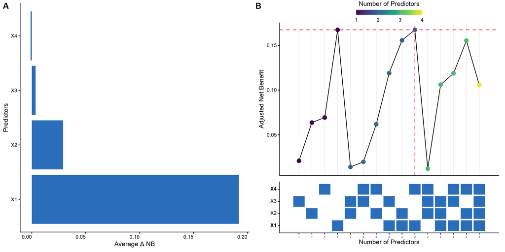

Figure 1. (A) Net benefit based variable importance for the simple illustration. NB: Net benefit. (B) All subset plot for the simple illustration.

This simple illustration serves as an example on how the best subset of predictors based on performance in statistical terms does not necessarily mean better cost-utility. Then, using the same data generating mechanism we generated a larger test dataset (N = 100,000) for the three possible models. **Table S1** presents the results of the three models in 1000 bootstrap samples. In **Figure S1** we illustrate the harm adjusted decision curves (A) of the three models and flexible calibration curves (B). The best model according to the harm-adjusted NB is always the NBvarsel model. The right plot illustrates that calibration for that model is slightly worse, showcasing the need to find a balance between statistical performance and decision-making.

# Case studies

## Ovarian cancer diagnosis - IOTA data

The variable selection procedure is detailed in the supplementary material of the original publication [43], we refer the reader there for details. The original ADNEX model utilized nine predictors: three clinical (age, serum CA125, and center type) and six ultrasound-based (lesion diameter, solid tissue proportion, >10 cyst locules, number of papillary projections, acoustic shadows, and ascites). While family history was initially considered, it was excluded during the variable selection process. For our analysis, missing CA125 values were handled via a regression-based imputation using all other ADNEX predictors, following recent methodological recommendations [46]. Then this model was applied to the development and validation dataset to impute missing values. In the validation dataset, some of the tumours were classified as uncertain for various reasons. In the published validation study, these values were also imputed with multiple imputation. We use one set of those imputed values for our analysis.

We extended the original predictor set with five additional features: bilateral masses (Yes/No), irregular internal cyst walls (Yes/No), Doppler color score (4 levels), maximum solid component diameter, and lesion-associated pain (Yes/No). The distribution of predictors by outcome for the training and test dataset is included in **Table S2**. In total 65,536 predictor combinations were evaluated across decision thresholds from 1% to 20% risk with 20-fold cross validation. This means that the average NB across those thresholds is the metric to optimize. We then compute discrimination in terms of AUC, OE ratio, clustered calibration and DCA [47]. Adjusted NB was also calculated with harms based on three group of variables: clinical history variables (no cost, should be available for all patients from the records), ultrasound based variables (TT = 200), blood based variables (TT = 80). We compared NB based variables selections to LASSO and backward elimination.

### Results

All models removed family history of ovarian cancer. The LASSO model also removed presence of papillary projections. NBvarsel models removed instead maximum diameter of the solid part of the tumour and in addition the adjusted NBvarsel removed CA125 biomarker. According to the variable importance calculations, the least important predictor was family history, and the most important one was the proportion of solid tissue (**Figure S2**).

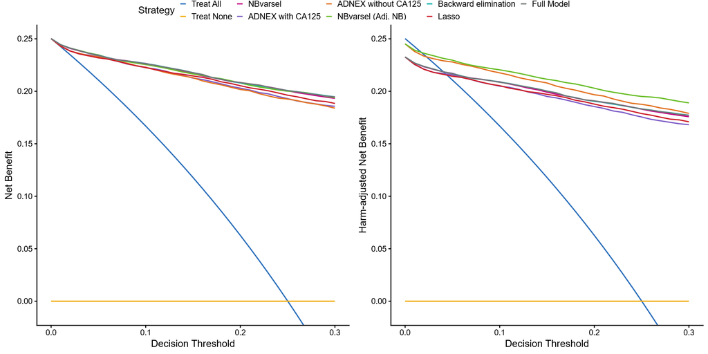

Figure 3. Decision curve analysis for unadjusted (left) and harm-adjusted (right) for the different variable selection procedures.

Table 3. Performance metrics of the different models varying the variable selection procedure.

| Model | Removed predictors<sup>a</sup> | AUC | O:E ratio | Brier | NB 10% risk | Cost | Adj. NB 10% risk |
| --- | --- | --- | --- | --- | --- | --- | --- |
| NBvarsel | Family history of ovarian cancer Maximum diameter of the solid part of the lesion | 0.961 | 0.975 | 0.063 | 0.227 | 0.018 | 0.209 |
| NBvarsel (harm adj.) | Family history of ovarian cancer Maximum diameter of the solid part of the lesion CA125 biomarker | 0.959 | 0.975 | 0.065 | 0.225 | 0.005 | 0.220 |
| ADNEX with CA125 | Family history of ovarian cancer Maximum diameter of the solid part of the lesion Irregular walls Bilateral tumours Doppler colour score Pain Presence of papillary projections | 0.953 | 1.031 | 0.070 | 0.222 | 0.018 | 0.205 |
| ADNEX without CA125 | Same as ADNEX above row plus CA125 | 0.950 | 1.066 | 0.074 | 0.223 | 0.005 | 0.218 |
| LASSO | Family history of ovarian cancer Presence of papillary projections | 0.953 | 0.929 | 0.072 | 0.223 | 0.018 | 0.205 |
| BE | Family history of ovarian cancer | 0.961 | 0.957 | 0.064 | 0.226 | 0.018 | 0.209 |
| Full model | None | 0.961 | 0.956 | 0.064 | 0.226 | 0.018 | 0.209 |

<sup>a</sup>For ADNEX the potential predictors where different and the data driven approach only removed family of ovarian cancer.

NB: Net Benefit

## Emergency department hospitalization - MIMIC IV ED (Large dimensional setting)

For the second case study we will use the well-known MIMIC IV emergency department (MIMIC IV ED) data combined with the MIMIC IV to predict the risk of hospitalization after visiting the emergency department [48-50]. MIMIC IV ED contains electronic health records data collected retrospectively from more than 425,000 emergency department stays in the Beth Israel Deaconess Medical Center in Boston, between 2011 and 2019. We use the benchmark proposed by Xie et al., but with the latest version of MIMIC IV (v3.1) and MIMIC ED (v2.2) [51]. The authors propose this benchmark to allow different model developers to make fair comparisons when using MIMIC IV data, therefore we followed the same procedure to obtain the training and test data according to their guidelines (see https://github.com/nliulab/mimic4ed-benchmark/tree/main). The training data contains 334,420 (80%) patients and the testing data 83,605 (20%).

### Results

The algorithm with group size = 1 trains 65 models, followed by 64 in the next step, and so on. For MIMIC IV-ED dataset, 8 predictors were removed using this algorithm and the process took 1.45 hours. The method with group size of two iteratively removes predictors in pairs, so it accounts for interactions of two predictors. This method is computationally more intensive because the algorithm needs to train 2017 models in first step, followed by 1953 and so on. In the data, the algorithm removed 12 predictors in 6 steps.

The most important predictors according to NBvarsel were triage acuity (Emergency Severity Index) and age of the patient (**Figure S6**). The most important variables for NBvarsel were similar to those reported in the original study calculated using RF [51]. Baseline model and groupwise approaches obtained similar AUC (0.81). Calibration was slightly closer to the diagonal for the groupwise variable selection but tended to overestimate high risk more than the baseline approach (**Figure S7**). NBvarsel models consistently ranked slightly higher for clinical utility across the decision curve except for very high thresholds were baseline was more useful (**Table 3, Figure 4**).

Table 3. Decision curve analysis table for MIMIC-ED comparison. Green cell indicates the best approach in terms of NB.

| Decision Threshold | Treat All | Treat None | Groupwise 1 | Groupwise 2 | Baseline |
| --- | --- | --- | --- | --- | --- |
| 0.05 | 0.446558 | 0,00 | 0.446955 | 0.446989 | 0.446701 |
| 0.10 | 0.415811 | 0,00 | 0.419859 | 0.419776 | 0.419434 |
| 0.15 | 0.381447 | 0,00 | 0.393222 | 0.393148 | 0.391698 |
| 0.20 | 0.342788 | 0,00 | 0.368241 | 0.368106 | 0.366575 |
| 0.25 | 0.298973 | 0,00 | 0.343488 | 0.343297 | 0.342252 |
| 0.30 | 0.248900 | 0,00 | 0.318166 | 0.318076 | 0.318014 |
| 0.35 | 0.191123 | 0,00 | 0.291692 | 0.291534 | 0.291323 |
| 0.40 | 0.123717 | 0,00 | 0.263772 | 0.263792 | 0.263816 |
| 0.45 | 0.044055 | 0,00 | 0.236028 | 0.236151 | 0.235611 |
| 0.50 | −0.051540 | 0,00 | 0.210179 | 0.210131 | 0.208504 |
| 0.55 | −0.168378 | 0,00 | 0.182517 | 0.182350 | 0.179455 |
| 0.60 | −0.314425 | 0,00 | 0.154022 | 0.153992 | 0.151390 |
| 0.65 | −0.502200 | 0,00 | 0.126612 | 0.126389 | 0.124094 |
| 0.70 | −0.752567 | 0,00 | 0.096705 | 0.096956 | 0.095429 |
| 0.75 | −1.103080 | 0,00 | 0.069015 | 0.069206 | 0.067508 |
| 0.80 | −1.628850 | 0,00 | 0.041923 | 0.041684 | 0.040344 |
| 0.85 | −2.505133 | 0,00 | 0.016678 | 0.016813 | 0.019321 |
| 0.90 | −4.257700 | 0,00 | 0.000395 | 0.001603 | 0.006495 |
| 0.95 | −9.515400 | 0,00 | −0.006040 | −0.005203 | 0.000167 |

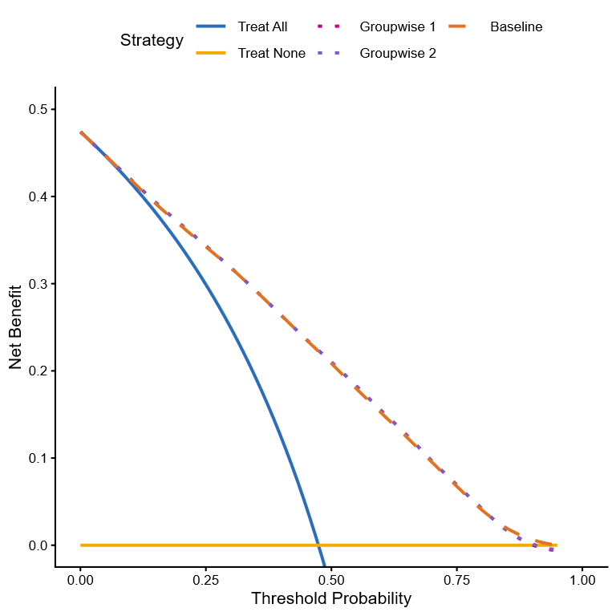

Figure 4. Decision curve analysis for the baseline model and the NBvarsel approaches in the hospitalization case study.

## Non typhoidal Salmonella (NTS) - DeNTS trial

The last case study will use prospective cohort data to predict the risk of non-typhoidal Salmonella (NTS) bloodstream infection in children under five to guide the choice of empirical antibiotics [53]. The dataset contains clinical information collected prospectively from 2,327 paediatric hospital admissions with severe febrile illness at the Kisantu district hospital in the Democratic Republic of Congo (**Table S4**). We use the a priori clinical predictors proposed by Tack et al., applying their exact variable definitions and restricted cubic spline transformations for continuous predictors. The authors propose this specific set of predictors based on a systematic literature review to ensure clinical relevance and avoid data-driven bias; therefore, we followed the same procedure to obtain our variables according to their guidelines. They propose 11 predictors to develop models for antibiotic triage, and they develop a simplified clinical scoring system alongside it, but we will focus on their main multivariable logistic regression (LR) model.

In their work, variables were selected using a double backward elimination process and the final model was fitted using Firth’s correction [54]. We will compare their approach to the introduced NBvarsel including splines for continuous predictors and then fitting the final model also using Firth’s correction. In our algorithm, continuous predictors were introduced either with splines or were removed. The authors propose the reasonable range of thresholds to be between 20% and 50% so this were the range of thresholds used in the variable selection procedure.

If we were to use the exhaustive variable selection approach as in previous case studies, this would mean evaluating exactly 2,047 combinations. No test data was available; therefore, we present apparent results first and then we corrected for optimism and compare the published approach and our algorithm across 1000 bootstrap samples. The bootstrap included the NB based variable selection and the published variable selection.

### Apparent performance

According to NBvarsel, the model removed age, nutritional status and haemoglobin levels and the most important predictors were malaria status, duration of fever and respiratory rate (**Figures S8-S9**). Individual risks varied considerably among the published model and the NBvarsel model(**Figure 5**). AUC was slightly higher for the published model (0.80 vs 0.79). The calibration of the model was closer to the diagonal for NBvarsel model for estimated risk below 45% but tended to estimate too low risks in higher estimated probabilities (Figure **S10**). The NBvarsel model had higher NB from decision thresholds of 25% till 55% (**Figure S11**).

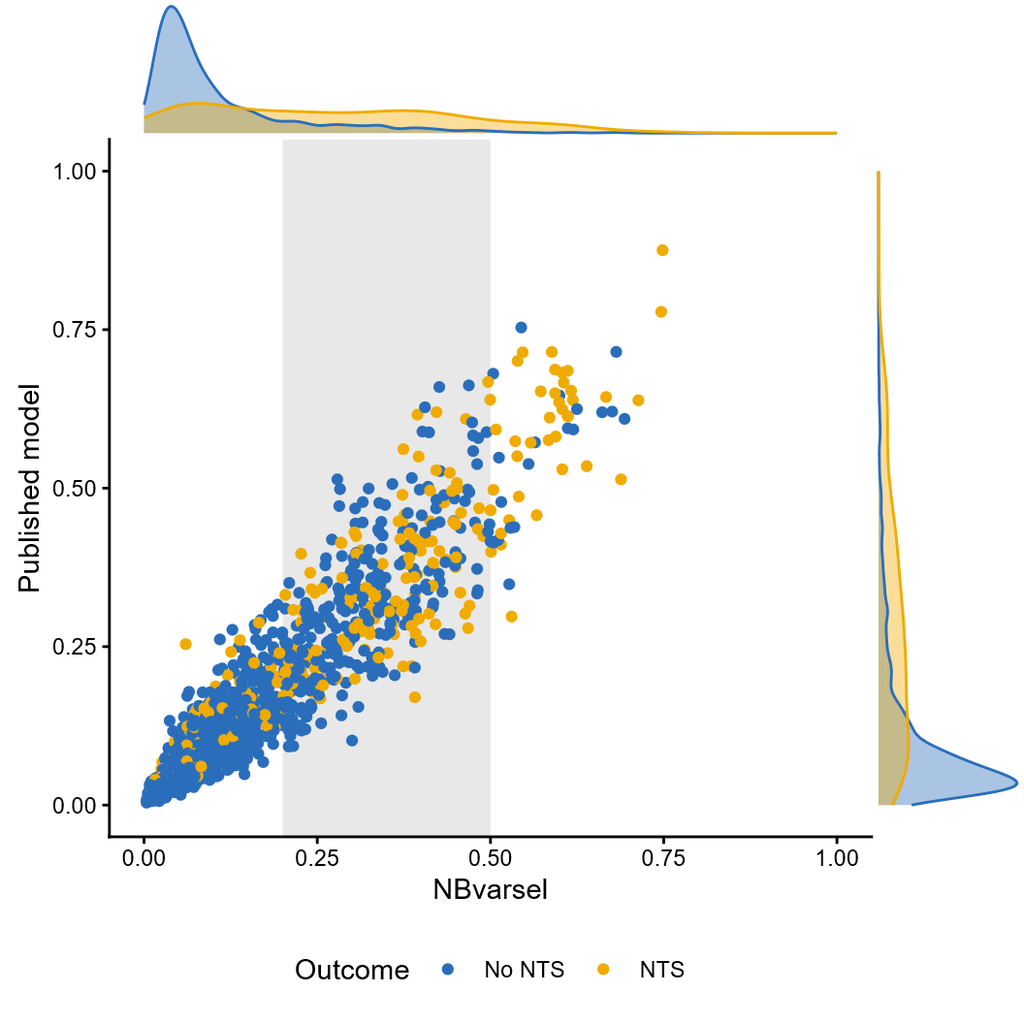

Figure 5. Distribution of individual risks for the model based on NB variable selection and the published model stratified by outcome. Plots in the margin depict densities per outcome. NTS: Non-typhoidal salmonella.

### Bootstrap results

Age at admission and malnutrition status were selected more than 50% of the bootstraps by the published strategy and were only picked up by NBvarsel 9% and 33% of the times. For the rest of predictors all were either selected more or less than 50% of the time in both strategies (**Figure S12**)

Table 4. DENTS case study bootstrap results.

| Characteristic | NBvarsel | Published model |
| --- | --- | --- |
| AUC | 0.776 (0.763 - 0.790) [0.696 - 0.841] | 0.781 (0.768 - 0.795) [0.714 - 0.835] |
| O:E ratio | 1.00 (0.93 - 1.07) [0.70 - 1.38] | 1.00 (0.93 - 1.07) [0.71 - 1.39] |
| Calibration Slope | 0.89 (0.81 - 0.98) [0.55 - 1.37] | 0.89 (0.81 - 0.97) [0.57 - 1.30] |
| Calibration Intercept | 0.00 (-0.10 - 0.10) [-0.47 - 0.45] | 0.00 (-0.09 - 0.10) [-0.46 - 0.46] |
| Brier score | 0.095 (0.091 - 0.099) [0.076 - 0.119] | 0.095 (0.092 - 0.099) [0.075 - 0.117] |

Median (Q1 - Q3) [Min - Max] across 1000 bootstrap runs.

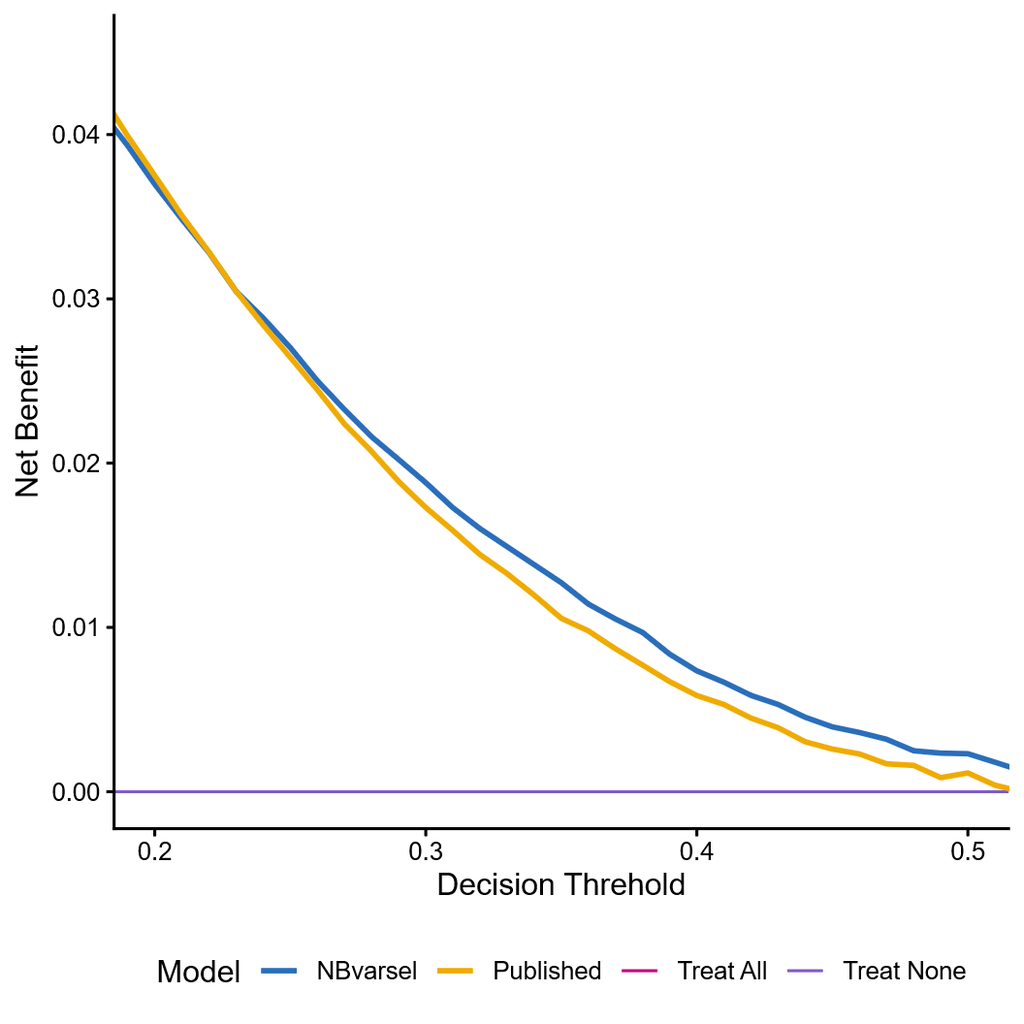

Figure 6. Optimism corrected decision curve analysis across reasonable thresholds based on 1000 bootstraps (Median results).

Table 5. Summary of results across the case studies. Comparator is the model with all the potential predictors. Positive refer to better performance for the NB variable selection.

[output not shown]

Difference between NBvarsel across reasonable thresholds and comparator.

# Discussion

## Summary of Key Findings

While classical statistical properties are widely used to build clinical prediction models, relying solely on them for variable selection often fails to optimise clinical benefit and to account for the real-world burden of measuring predictors. To address this gap, we developed and implemented a variable selection algorithm as an easy-to-use R package that determines the optimal subset of predictors by exhaustively exploring all predictor combinations and maximizing clinical utility, measured via harm-adjusted or traditional NB. Through our simple illustration and three case studies, we showed that this decision analysis-based approach effectively reduces model complexity, maintaining comparable discrimination, calibration and clinical utility. In the ovarian cancer case study, adjusting for measurement harm successfully removed the CA125 biomarker, a test requiring a blood draw, while maintaining comparable performance to traditional backward elimination and LASSO methods. Furthermore, we showed that by using a groupwise elimination approach, this methodology can be successfully scaled to high-dimensional datasets like MIMIC IV-ED, yielding slightly higher clinical utility across decision thresholds compared to baseline models, and reducing the final parameters in the model (**Table 5**).

## Contextualization Within Existing Literature

There is growing recognition in the field of clinical prediction modelling that traditional performance measures are insufficient to guarantee a model’s clinical value (Steyerberg, 2019; Van Calster et al., 2025). However, embedding utility directly into the variable selection phase has historically been difficult. While Baker et al. (2012) discussed the use of NB to evaluate new markers, it was not operationalized as an automated variable selection algorithm. Preliminary efforts to add utility to variable selection have struggled with the generation of utility values and the complexity of the methods [55]. Fouskakis and colleagues proposed using stochastic optimization to select the model with the best cost-adjusted Bayesian Information Criterion (BIC). The cost-adjusted BIC extends standard model selection by penalizing the total measurement cost of predictors rather than solely the number of variables included. However, implementing this method requires the specification of a cost-penalized prior, a task that proves difficult for clinicians who must quantify the trade-off between statistical gain and data collection burden. Zhao and Yu, developed a cost-sensitive variable selection method based on the -norm [56]. Their work is mainly methodological, without linking it to underlying utility of predictors. The *glmnet* package in R allows to use weights that can represent misclassification costs [57]. The misclassification costs are used to estimate the model coefficients, therefore providing miscalibrated models, similar to class imbalance corrections [58]. The package also allows to determine penalty factors (i.e. predictor costs). The predictor’s cost in the package can only be determined in relative terms without clinical translation, and they do not provide a combined cost approach which is common in medical settings. Our approach bridges this methodological gap by using “simple” metrics such as NB and the TT that have a clear clinical meaning, providing a much more intuitive scale for clinicians to quantify the harm-to-benefit ratio.

## Limitations

Despite its advantages, this methodology has several limitations. First, determining the specific “harm” of measuring a predictor is subjective, highly context-dependent, and challenging to quantify precisely prior to model development (**Box 2**). There might be situations where the harm of measuring a predictor is established and we advise therefore to use the costs. However, for most situations where this is not possible, the algorithm can be safely used without costs and provide a variable importance metric based on NB. Second, this is a data-driven method and therefore it is prone to overfit if sample size is limited. We recommend using the algorithm at least with the minimum sample size recommended by Riley’s method [28]. Third, the exhaustive evaluation of all predictor combinations is computationally intensive and becomes infeasible with many candidate predictors. This is a process that should be done only once for model development, and we provide and option to parallelize the process to reduce considerably the running time. Lastly, we only developed the variable selection methodology for logistic regression, but we aim to increase to other modelling algorithms as part of *NBvarsel* package.

## Implications

Prediction models that require burdensome, invasive, or expensive data collection for only marginal statistical gains are rarely adopted in routine care [10]. By integrating clinical utility directly into the model training pipeline, developers can ensure that their final models are both statistically rigorous and practically viable. The open-source *NBvarsel* (https://lasaibarrenada.github.io/NB_varsel/) R package and its associated visualizations provide researchers with accessible tools to make informed, utility-driven decisions about variable selection.

## Future Research

Future research should prioritize extensive, controlled evaluations of this methodology. Specifically, simulation studies are needed to determine the sample sizes required to prevent overfitting, compare the relative performance of exhaustive versus groupwise approaches, and assess the impact of threshold mismatches between training and testing phases. We also plan to expand the methodology’s analytical capabilities. For the current binary logistic regression framework, future updates will introduce full control over variable interactions and spline terms. Furthermore, while we currently use the average NB across a reasonable threshold range, we aim to implement kernel smoothing to dynamically weight specific target thresholds. Another related approach to using clinical utility directly into parameter estimation would involve using harm-adjusted NB as the optimization criterion for a loss function in deep learning architectures [59]. Although the algorithm’s fundamental rationale applies to any prediction model, the current software is limited to binary logistic regression; future iterations will support survival and time-to-event outcomes, alongside other modelling algorithms. Finally, this package is open-source and intended for continuous development, and we actively welcome contributions from the research community.

## Conclusion

Clinical utility should not be an afterthought reserved only for external validation. By integrating a harm-adjusted NB metric directly into the variable selection process, researchers can produce prediction models that maximize patient benefit while minimizing unnecessary clinical burden.

**Author contributions**

Conceptualization: AV, LW, BVC, ES. Methodology: LB, AV, LW, BVC, ES. Investigation: LB, AV, LW, BVC, ES. Visualization: LB. Funding acquisition: BVC, DT, LB, . Project administration: LB. Supervision: AV, LW, BVC, ES. Writing - original draft: LB, AV. Writing - review & editing: LB, AV, LW, BVC, ES, DT.

**Funding**

**Conflicts of interest**

**Data availability**

**Disclaimer**

# References

1 Steyerberg EW. *Clinical Prediction Models: A Practical Approach to Development, Validation, and Updating*. Cham: Springer International Publishing 2019.

2 James G, Witten D, Hastie T, *et al.* *An Introduction to Statistical Learning: with Applications in R*. New York, NY: Springer US 2021.

3 Chowdhury MZI, Turin TC. Variable selection strategies and its importance in clinical prediction modelling. *Fam Med Community Health*. 2020;8:e000262. doi: 10.1136/fmch-2019-000262

4 Heinze G, Wallisch C, Dunkler D. Variable selection - A review and recommendations for the practicing statistician. *Biom J*. 2018;60:431-49. doi: 10.1002/bimj.201700067

5 Nguyen M. *Foundations of data analysis*. Springer Cham 2025.

6 Archer KJ, Kimes RV. Empirical characterization of random forest variable importance measures. *Computational Statistics & Data Analysis*. 2008;52:2249-60. doi: 10.1016/j.csda.2007.08.015

7 Zhang Z, Trevino V, Hoseini SS, *et al.* Variable selection in Logistic regression model with genetic algorithm. *Annals of Translational Medicine*. 2018;6:45-45. doi: 10.21037/atm.2018.01.15

8 Van Calster B, Collins GS, Vickers AJ, *et al.* Evaluation of performance measures in predictive artificial intelligence models to support medical decisions: overview and guidance. *The Lancet Digital Health*. 2025;0. doi: 10.1016/j.landig.2025.100916

9 Van Calster B, Wynants L, Verbeek JFM, *et al.* Reporting and Interpreting Decision Curve Analysis: A Guide for Investigators. *Eur Urol*. 2018;74:796-804. doi: 10.1016/j.eururo.2018.08.038

10 Wyatt JC, Altman DG. Commentary: Prognostic models: clinically useful or quickly forgotten? *BMJ*. 1995;311:1539-41. doi: 10.1136/bmj.311.7019.1539

11 Vickers AJ, Elkin EB. Decision Curve Analysis: A Novel Method for Evaluating Prediction Models. *Med Decis Making*. 2006;26:565-74. doi: 10.1177/0272989X06295361

12 Vickers AJ, van Calster B, Steyerberg EW. A simple, step-by-step guide to interpreting decision curve analysis. *Diagn Progn Res*. 2019;3:18. doi: 10.1186/s41512-019-0064-7

13 Baker SG, Calster BV, Steyerberg EW. Evaluating a New Marker for Risk Prediction Using the Test Tradeoff: An Update. *The International Journal of Biostatistics*. 2012;8:1-37. doi: 10.1515/1557-4679.1395

14 Gneiting T, Raftery AE. Strictly Proper Scoring Rules, Prediction, and Estimation. *Journal of the American Statistical Association*. 2007;102:359-78. doi: 10.1198/016214506000001437

15 Barreñada L, Ledger A, Dhiman P, *et al.* ADNEX risk prediction model for diagnosis of ovarian cancer: systematic review and meta-analysis of external validation studies. *bmjmed*. 2024;3:e000817. doi: 10.1136/bmjmed-2023-000817

16 Wynants L, Van Calster B, Collins GS, *et al.* Prediction models for diagnosis and prognosis of covid-19: systematic review and critical appraisal. *BMJ*. 2020;369:m1328. doi: 10.1136/bmj.m1328

17 Collins GS, Moons KGM, Dhiman P, *et al.* TRIPOD+AI statement: updated guidance for reporting clinical prediction models that use regression or machine learning methods. *BMJ*. 2024;385:e078378. doi: 10.1136/bmj-2023-078378

18 Moons KGM, Damen JAA, Kaul T, *et al.* PROBAST+AI: an updated quality, risk of bias, and applicability assessment tool for prediction models using regression or artificial intelligence methods. *BMJ*. 2025;388:e082505. doi: 10.1136/bmj-2024-082505

19 Steyerberg EW, Schemper M, Harrell FE. Logistic regression modeling and the number of events per variable: selection bias dominates. *Journal of Clinical Epidemiology*. 2011;64:1464-5. doi: 10.1016/j.jclinepi.2011.06.016

20 Concato J, Peduzzi P, Holford TR, *et al.* Importance of events per independent variable in proportional hazards analysis I. Background, goals, and general strategy. *Journal of Clinical Epidemiology*. 1995;48:1495-501. doi: 10.1016/0895-4356(95)00510-2

21 Peduzzi P, Concato J, Kemper E, *et al.* A simulation study of the number of events per variable in logistic regression analysis. *Journal of Clinical Epidemiology*. 1996;49:1373-9. doi: 10.1016/S0895-4356(96)00236-3

22 Courvoisier DS, Combescure C, Agoritsas T, *et al.* Performance of logistic regression modeling: beyond the number of events per variable, the role of data structure. *J Clin Epidemiol*. 2011;64:993-1000. doi: 10.1016/j.jclinepi.2010.11.012

23 van Smeden M, de Groot JAH, Moons KGM, *et al.* No rationale for 1 variable per 10 events criterion for binary logistic regression analysis. *BMC Medical Research Methodology*. 2016;16:163. doi: 10.1186/s12874-016-0267-3

24 Vittinghoff E, McCulloch CE. Relaxing the Rule of Ten Events per Variable in Logistic and Cox Regression. *American Journal of Epidemiology*. 2007;165:710-8. doi: 10.1093/aje/kwk052

25 Archer L, Snell KIE, Ensor J, *et al.* Minimum sample size for external validation of a clinical prediction model with a continuous outcome. *Statistics in Medicine*. 2021;40:133-46. doi: 10.1002/sim.8766

26 Pate A, Riley RD, Collins GS, *et al.* Minimum sample size for developing a multivariable prediction model using multinomial logistic regression. *Stat Methods Med Res*. 2023;32:555-71. doi: 10.1177/09622802231151220

27 Riley RD, Snell KIE, Ensor J, *et al.* Minimum sample size for developing a multivariable prediction model: Part I - Continuous outcomes. *Stat Med*. 2019;38:1262-75. doi: 10.1002/sim.7993

28 Riley RD, Snell KI, Ensor J, *et al.* Minimum sample size for developing a multivariable prediction model: PART II ‐ binary and time‐to‐event outcomes. *Stat Med*. 2019;38:1276-96. doi: 10.1002/sim.7992

29 Riley RD, Collins GS, Ensor J, *et al.* Minimum sample size calculations for external validation of a clinical prediction model with a time-to-event outcome. *Statistics in Medicine*. 2022;41:1280-95. doi: 10.1002/sim.9275

30 Riley RD, Snell KIE, Archer L, *et al.* Evaluation of clinical prediction models (part 3): calculating the sample size required for an external validation study. *BMJ*. 2024;384:e074821. doi: 10.1136/bmj-2023-074821

31 Riley RD, Whittle R, Sadatsafavi M, *et al.* A general sample size framework for developing or updating a clinical prediction model. 2025.

32 Austin PC, Lee DS, Wang B. The relative data hungriness of unpenalized and penalized logistic regression and ensemble-based machine learning methods: the case of calibration. *Diagn Progn Res*. 2024;8:15. doi: 10.1186/s41512-024-00179-z

33 van der Ploeg T, Austin PC, Steyerberg EW. Modern modelling techniques are data hungry: a simulation study for predicting dichotomous endpoints. *BMC Med Res Methodol*. 2014;14:137. doi: 10.1186/1471-2288-14-137

34 Harrell FE. *Regression Modeling Strategies: With Applications to Linear Models, Logistic and Ordinal Regression, and Survival Analysis*. Cham: Springer International Publishing 2015.

35 Dwivedi R, Dave D, Naik H, *et al.* Explainable AI (XAI): Core Ideas, Techniques, and Solutions. *ACM Comput Surv*. 2023;55:194:1-194:33. doi: 10.1145/3561048

36 Lundberg S, Lee S-I. A Unified Approach to Interpreting Model Predictions. 2017.

37 Ribeiro MT, Singh S, Guestrin C. “Why Should I Trust You?”: Explaining the Predictions of Any Classifier. *Proceedings of the 22nd ACM SIGKDD International Conference on Knowledge Discovery and Data Mining*. New York, NY, USA: Association for Computing Machinery 2016:1135-44.

38 Breiman L. Random Forests. *Machine Learning*. 2001;45:5-32. doi: 10.1023/A:1010933404324

39 Carley ME, Klingele CJ, Gebhart JB, *et al.* Laparoscopy versus laparotomy in the management of benign unilateral adnexal masses. *J Am Assoc Gynecol Laparosc*. 2002;9:321-6. doi: 10.1016/s1074-3804(05)60411-2

40 Froyman W, Landolfo C, De Cock B, *et al.* Risk of complications in patients with conservatively managed ovarian tumours (IOTA5): a 2-year interim analysis of a multicentre, prospective, cohort study. *Lancet Oncol*. 2019;20:448-58. doi: 10.1016/S1470-2045(18)30837-4

41 Timmerman D, Planchamp F, Bourne T, *et al.* ESGO/ISUOG/IOTA/ESGE Consensus Statement on pre-operative diagnosis of ovarian tumors. *Int J Gynecol Cancer*. 2021;31:961-82. doi: 10.1136/ijgc-2021-002565

42 J. Kaijser, Tom Bourne, Lil Valentin, *et al.* Improving strategies for diagnosing ovarian cancer: a summary of the International Ovarian Tumor Analysis (IOTA) studies. *Ultrasound in Obstetrics & Gynecology*. Published Online First: 2013. doi: 10.1002/uog.12323

43 Van Calster B, Hoorde KV, Valentin L, *et al.* Evaluating the risk of ovarian cancer before surgery using the ADNEX model to differentiate between benign, borderline, early and advanced stage invasive, and secondary metastatic tumours: prospective multicentre diagnostic study. *BMJ*. 2014;349:g5920. doi: 10.1136/bmj.g5920

44 Barreñada L, Ledger A, Kotlarz A, *et al.* Head-to-head comparison of the RMI and ADNEX models to estimate the risk of ovarian malignancy: systematic review and meta-analysis of external validation studies. 2024;2024.11.29.24318146.

45 Van Calster B, Valentin L, Froyman W, *et al.* Validation of models to diagnose ovarian cancer in patients managed surgically or conservatively: multicentre cohort study. *BMJ*. 2020;370:m2614. doi: 10.1136/bmj.m2614

46 Sisk R, Sperrin M, Peek N, *et al.* Imputation and missing indicators for handling missing data in the development and deployment of clinical prediction models: A simulation study. *Stat Methods Med Res*. 2023;9622802231165001. doi: 10.1177/09622802231165001

47 Barreñada L, Campo BDC, Wynants L, *et al.* Clustered flexible calibration plots for binary outcomes using random effects modeling. *Res Synth Methods*. 2026;17:567-88. doi: 10.1017/rsm.2025.10046

48 Johnson A, Bulgarelli L, Pollard T, *et al.* MIMIC-IV-ED. *PhysioNet*. Published Online First: January 2023. doi: 10.13026/5ntk-km72

49 Johnson A, Bulgarelli L, Pollard T, *et al.* MIMIC-IV. *PhysioNet*. Published Online First: October 2024. doi: 10.13026/kpb9-mt58

50 Johnson A, Bulgarelli L, Shen L, *et al.* MIMIC-IV, a freely accessible electronic health record dataset. *Sci Data*. 2023;10:1. doi: 10.1038/s41597-022-01899-x

51 Xie F, Zhou J, Lee JW, *et al.* Benchmarking emergency department prediction models with machine learning and public electronic health records. *Sci Data*. 2022;9:658. doi: 10.1038/s41597-022-01782-9

52 on behalf of the Topic Group ‘Evaluating diagnostic tests and prediction models’ of the STRATOS initiative, Wynants L, van Smeden M, *et al.* Three myths about risk thresholds for prediction models. *BMC Med*. 2019;17:192. doi: 10.1186/s12916-019-1425-3

53 Tack B, Vita D, Mbuyamba J, *et al.* Developing a clinical prediction model to modify empirical antibiotics for non-typhoidal Salmonella bloodstream infection in children under-five in the Democratic Republic of Congo. *BMC Infect Dis*. 2025;25:122. doi: 10.1186/s12879-024-10319-x

54 Puhr R, Heinze G, Nold M, *et al.* Firth’s logistic regression with rare events: accurate effect estimates and predictions? *Stat Med*. 2017;36:2302-17. doi: 10.1002/sim.7273

55 Fouskakis D, Ntzoufras I, Draper D. Bayesian Variable Selection Using Cost-Adjusted BIC, with Application to Cost-Effective Measurement of Quality of Health Care. *The Annals of Applied Statistics*. 2009;3:663-90.

56 Zhao H, Yu S. Cost-sensitive feature selection via the *ℓ_2,1-norm. _International Journal of Approximate Reasoning*. 2019;104:25-37. doi: 10.1016/j.ijar.2018.10.017

57 Friedman J, Hastie T, Tibshirani R. Regularization Paths for Generalized Linear Models via Coordinate Descent. *J Stat Softw*. 2010;33:1-22.

58 van den Goorbergh R, van Smeden M, Timmerman D, *et al.* The harm of class imbalance corrections for risk prediction models: illustration and simulation using logistic regression. *J Am Med Inform Assoc*. 2022;29:1525-34. doi: 10.1093/jamia/ocac093

59 Vickers A, Hollingsworth A, Bozzo A, *et al.* Hypothesis: Net benefit as an objective function during development of machine learning algorithms for medical applications. *International Journal of Medical Informatics*. 2025;197:105844. doi: 10.1016/j.ijmedinf.2025.105844